# Phenomenon name meta-analysis

#### Published studies

```
##
## Random-Effects Model (k = 22; tau^2 estimator: REML)
##
## tau^2 (estimated amount of total heterogeneity): 1.1441 (SE = 0.3656)
## tau (square root of estimated tau^2 value):      1.0696
## I^2 (total heterogeneity / total variability):   98.23%
## H^2 (total variability / sampling variability):  56.46
##
## Test for Heterogeneity:
## Q(df = 21) = 893.4633, p-val < .0001
##
## Model Results:
##
## estimate      se    zval    pval   ci.lb   ci.ub
##   0.5103  0.2321  2.1984  0.0279  0.0553  0.9652  *
##
## ---
## Signif. codes:  0 '***' 0.001 '**' 0.01 '*' 0.05 '.' 0.1 ' ' 1
```

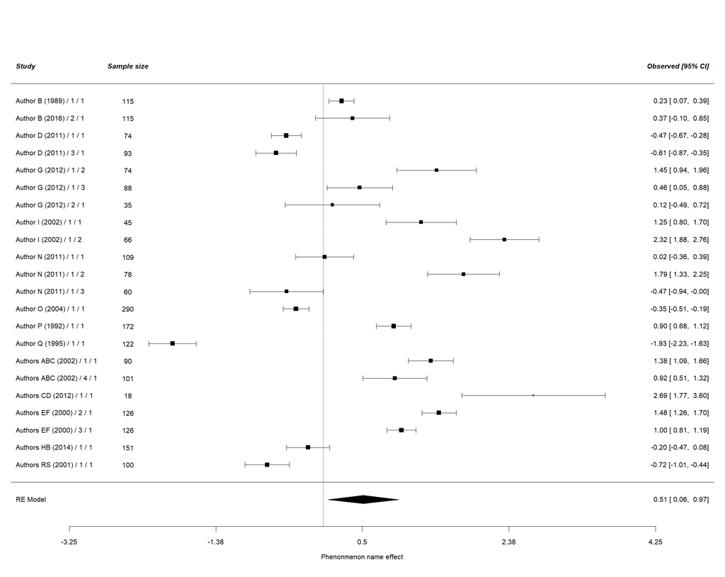

Published

#### Unpublished studies

```
##
## Random-Effects Model (k = 2; tau^2 estimator: REML)
##
## tau^2 (estimated amount of total heterogeneity): 0.0117 (SE = 0.0567)
## tau (square root of estimated tau^2 value):      0.1080
## I^2 (total heterogeneity / total variability):   29.12%
## H^2 (total variability / sampling variability):  1.41
##
## Test for Heterogeneity:
## Q(df = 1) = 1.4109, p-val = 0.2349
##
## Model Results:
##
## estimate      se    zval    pval   ci.lb   ci.ub
##   0.8796  0.1415  6.2148  <.0001  0.6022  1.1570  ***
##
## ---
## Signif. codes:  0 '***' 0.001 '**' 0.01 '*' 0.05 '.' 0.1 ' ' 1
```

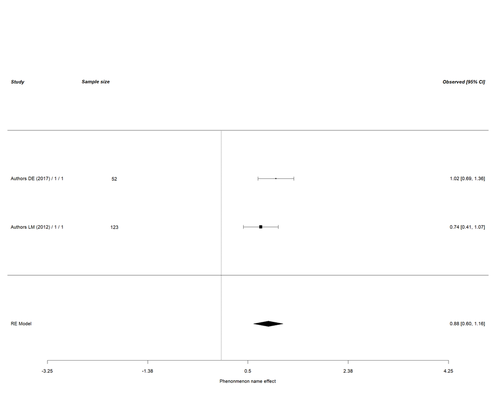

Unpublished

### Comparing published versus unpublised study groups

```
##   estimate stderror numstudies                meta   tau2
## 1     0.51    0.232         22   Published studies 1.1441
## 2     0.88    0.142          2 Unpublished studies 0.0117
```

```
##
## Fixed-Effects with Moderators Model (k = 2)
##
## I^2 (residual heterogeneity / unaccounted variability): 0.00%
## H^2 (unaccounted variability / sampling variability):   1.00
##
## Test for Residual Heterogeneity:
## QE(df = 0) = 0.000, p-val = 1.000
##
## Test of Moderators (coefficient 2):
## QM(df = 1) = 1.845, p-val = 0.174
##
## Model Results:
##
##                                  estimate     se   zval   pval   ci.lb  ci.ub
## intrcpt                             0.510  0.232  2.198  0.028   0.055  0.965
## factor(meta)Unpublished studies     0.369  0.272  1.358  0.174  -0.164  0.902
##
## intrcpt                          *
## factor(meta)Unpublished studies
##
## ---
## Signif. codes:  0 '***' 0.001 '**' 0.01 '*' 0.05 '.' 0.1 ' ' 1
```

### Possible Moderator 4 analyses

```
##
## Mixed-Effects Model (k = 51; tau^2 estimator: REML)
##
## tau^2 (estimated amount of residual heterogeneity):     2.8360 (SE = 0.5829)
## tau (square root of estimated tau^2 value):             1.6840
## I^2 (residual heterogeneity / unaccounted variability): 99.08%
## H^2 (unaccounted variability / sampling variability):   108.65
## R^2 (amount of heterogeneity accounted for):            1.58%
##
## Test for Residual Heterogeneity:
## QE(df = 49) = 3043.5722, p-val < .0001
##
## Test of Moderators (coefficient 2):
## QM(df = 1) = 1.9148, p-val = 0.1664
##
## Model Results:
##
##                                estimate      se     zval    pval    ci.lb
## intrcpt                          0.7090  0.3547   1.9987  0.0456   0.0137
## Possible.Moderator.4Category2   -0.6617  0.4782  -1.3837  0.1664  -1.5990
##                                 ci.ub
## intrcpt                        1.4043  *
## Possible.Moderator.4Category2  0.2755
##
## ---
## Signif. codes:  0 '***' 0.001 '**' 0.01 '*' 0.05 '.' 0.1 ' ' 1
```

#### Possible Moderator 4 Category 1 studies

```
##
## Random-Effects Model (k = 14; tau^2 estimator: REML)
##
## tau^2 (estimated amount of total heterogeneity): 1.8421 (SE = 0.7406)
## tau (square root of estimated tau^2 value):      1.3572
## I^2 (total heterogeneity / total variability):   98.95%
## H^2 (total variability / sampling variability):  95.24
##
## Test for Heterogeneity:
## Q(df = 13) = 583.1206, p-val < .0001
##
## Model Results:
##
## estimate      se    zval    pval   ci.lb   ci.ub
##   0.7227  0.3673  1.9677  0.0491  0.0028  1.4426  *
##
## ---
## Signif. codes:  0 '***' 0.001 '**' 0.01 '*' 0.05 '.' 0.1 ' ' 1
```

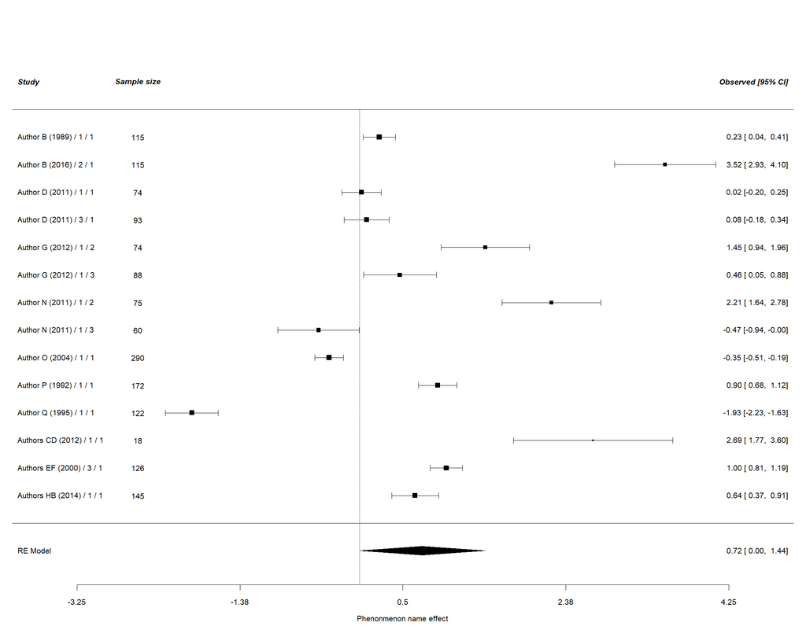

Mod4Cat1